# Flu Survey Data

## 0.1 Working analysis

```
##          Q13
## Q1        No, never Refused Yes, every year Yes, some years
##   No            260       4             143              81
##   Refused         2      10               4               0
##   Yes           557       4             761             342
```

```
## Number of cases in table: 2168
## Number of factors: 2
## Test for independence of all factors:
##  Chisq = 813.4, df = 6, p-value = 1.981e-172
##  Chi-squared approximation may be incorrect
```

```
## Source: local data frame [3 x 2]
##
##        Q1 count
##    (fctr) (int)
## 1      No   488
## 2 Refused    16
## 3     Yes  1664
```

```
## Source: local data frame [6 x 3]
## Groups: Q1 [?]
##
##        Q1 PPGENDER count
##    (fctr)   (fctr) (int)
## 1      No   Female   205
## 2      No     Male   283
## 3 Refused   Female     4
## 4 Refused     Male    12
## 5     Yes   Female   888
## 6     Yes     Male   776
```

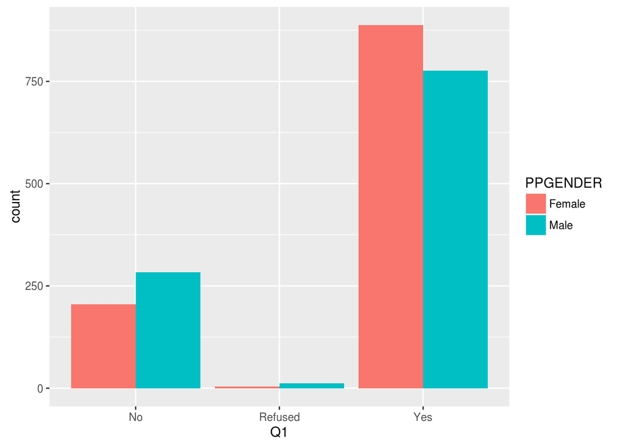

```
## Source: local data frame [6 x 3]
## Groups: Q2 [?]
##
##        Q2 PPGENDER count
##    (fctr)   (fctr) (int)
## 1      No   Female   858
## 2      No     Male   877
## 3 Refused   Female     5
## 4 Refused     Male    14
## 5     Yes   Female   234
## 6     Yes     Male   180
```

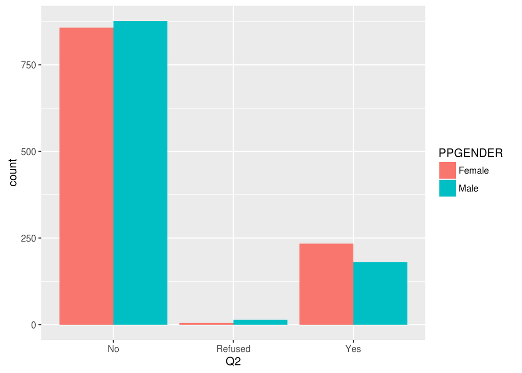

## 0.2 Survey data by question

## 0.3 Summary tables & plots

#### 0.3.0.1 Q1. Before receiving this survey, did you know influenza is different from the stomach flu?

```
##        Q1
##  No     : 488
##  Refused:  16
##  Yes    :1664
```

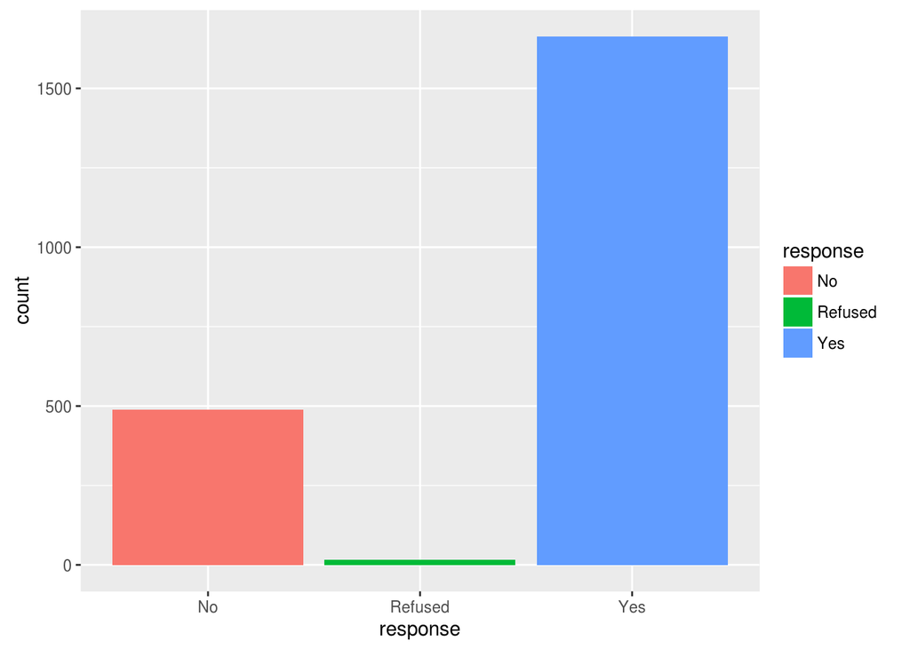

#### 0.3.0.2 Q2. Have you had an illness with influenza like symptoms since August 2015?

```
##        Q2
##  No     :1735
##  Refused:  19
##  Yes    : 414
```

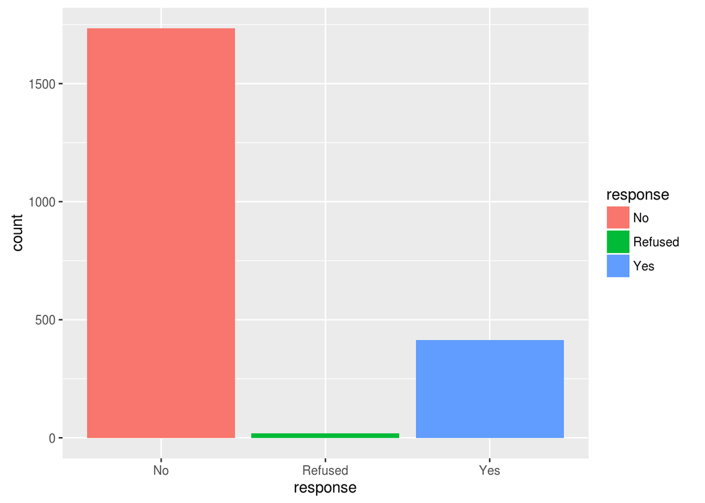

#### 0.3.0.3 Q3. Has any other person in your household had an illness with influenza like symptoms since August 2015?

```
##           Q3
##  Don_t know: 161
##  No        :1608
##  Refused   :  16
##  Yes       : 383
```

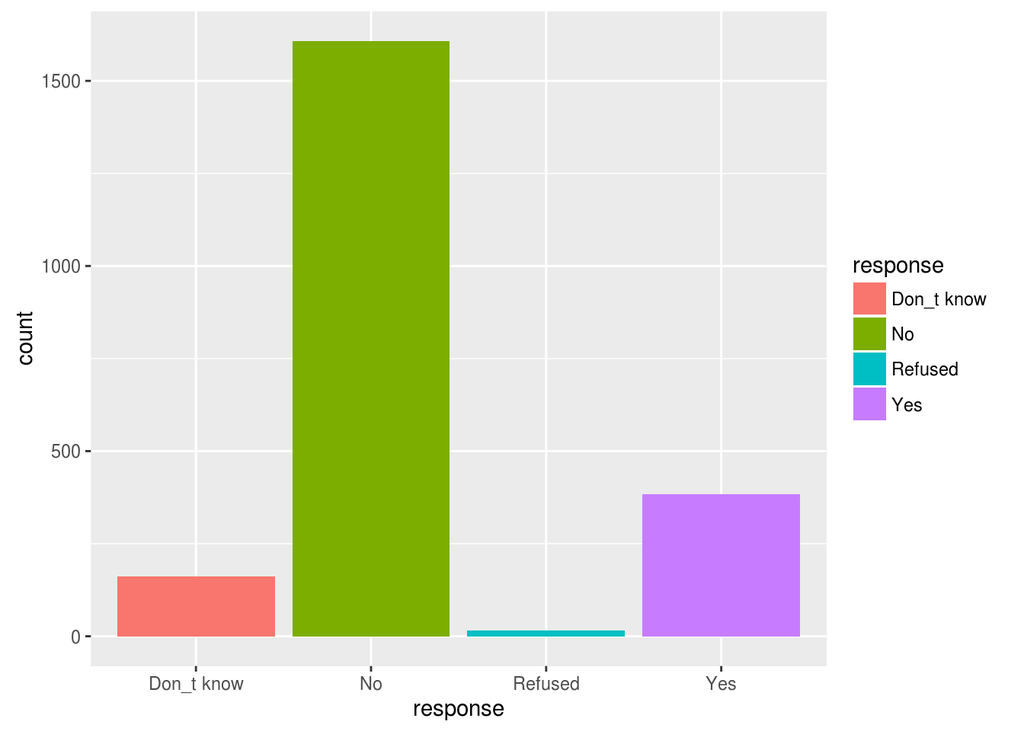

#### 0.3.0.4 Q4. Does your job require you to have a lot of contact with the public?

```
##                                                         Q4
##  No, I don_t work                                        :779
##  No, my job does not require much contact with the public:620
##  Refused                                                 : 18
##  Yes                                                     :751
```

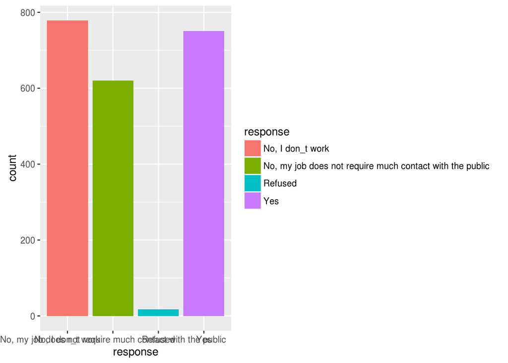

#### 0.3.0.5 Q5. Do you have a car that you can use to travel to work?

```
##        Q5
##  No     : 133
##  Refused:   3
##  Yes    :1235
##  NA's   : 797
```

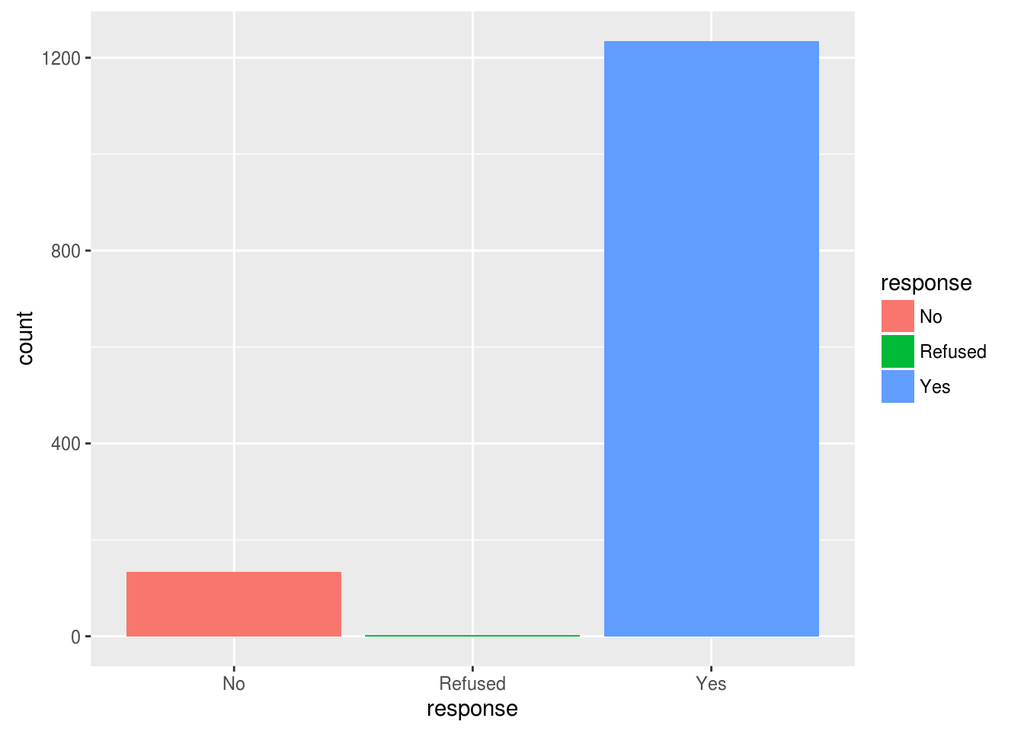

#### 0.3.0.6 Q6. Do you regularly use public transportation?

```
##        Q6
##  No     :1959
##  Refused:  15
##  Yes    : 194
```

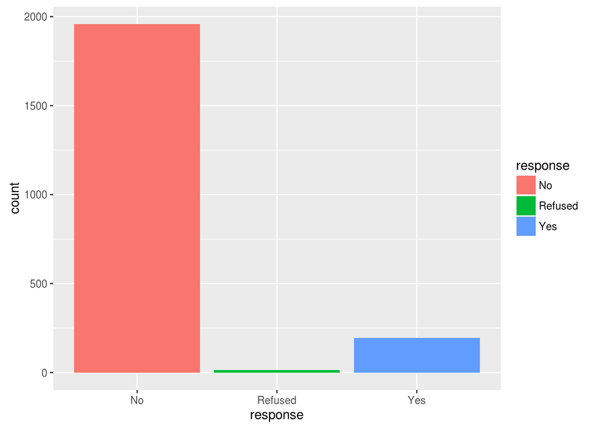

#### 0.3.0.7 Q7. What types of public transportation do you regularly use?

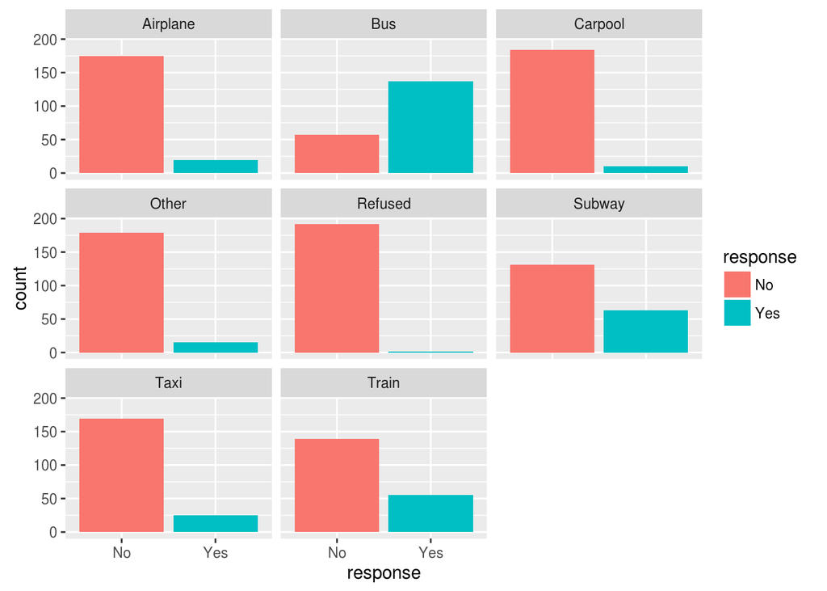

```
##    Bus       Carpool      Subway      Train        Taxi      Airplane
##  No  :  57   No  : 184   No  : 131   No  : 139   No  : 169   No  : 175
##  Yes : 137   Yes :  10   Yes :  63   Yes :  55   Yes :  25   Yes :  19
##  NA's:1974   NA's:1974   NA's:1974   NA's:1974   NA's:1974   NA's:1974
##
##
##
##
##   Other      Refused         Other text
##  No  : 179   No  : 192            :2153
##  Yes :  15   Yes :   2   bike,walk:   1
##  NA's:1974   NA's:1974   car      :   1
##                          ferry    :   1
##                          Ferry    :   1
##                          Horse    :   1
##                          (Other)  :  10
```

#### 0.3.0.8 Q8. For what types of activities do you regularly use public transportation?

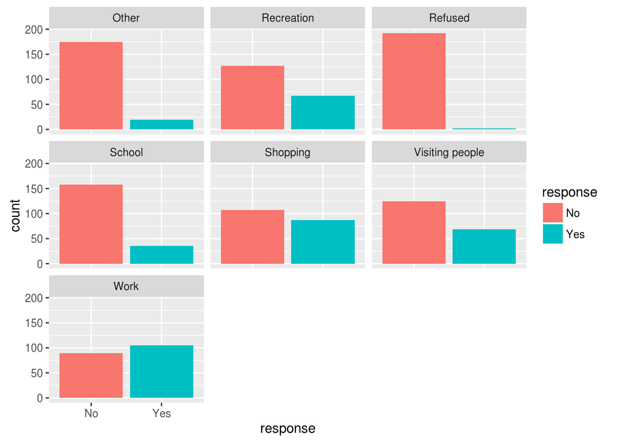

```
##    Work       School     Shopping    Visiting people Recreation
##  No  :  89   No  : 158   No  : 107   No  : 125       No  : 127
##  Yes : 105   Yes :  36   Yes :  87   Yes :  69       Yes :  67
##  NA's:1974   NA's:1974   NA's:1974   NA's:1974       NA's:1974
##
##
##
##
##   Other      Refused                     Other text
##  No  : 175   No  : 192                        :2149
##  Yes :  19   Yes :   2   church, adult ed     :   1
##  NA's:1974   NA's:1974   doc. app.            :   1
##                          Doctor               :   1
##                          Doctor's appointments:   1
##                          doctors appts. etc   :   1
##                          (Other)              :  14
```

#### 0.3.0.9 Q9. Do other members of your household regularly use public transportation?

```
##           Q9
##  Don_t know:  32
##  No        :1935
##  Refused   :  18
##  Yes       : 183
```

#### 0.3.0.10 Q10. What types of public transportation do other members of your household regularly use?

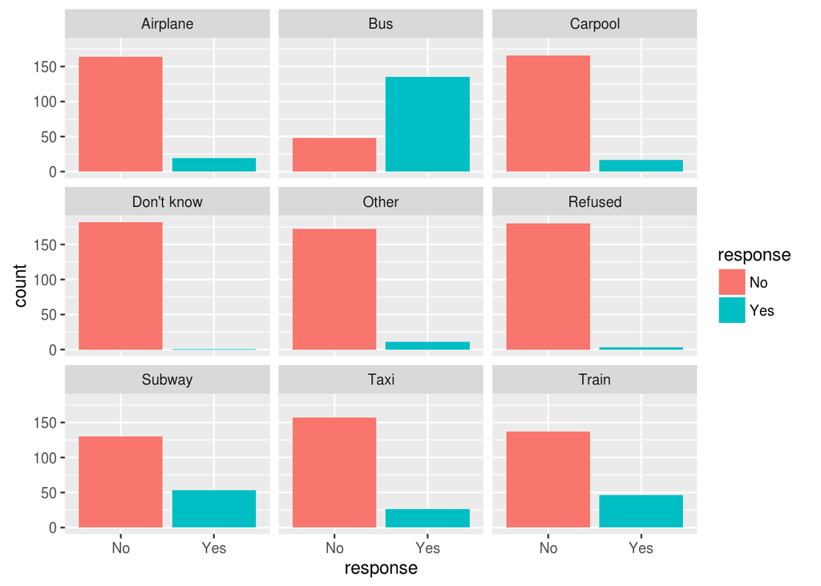

```
##    Bus       Carpool      Subway      Train        Taxi      Airplane
##  No  :  48   No  : 166   No  : 130   No  : 137   No  : 157   No  : 164
##  Yes : 135   Yes :  17   Yes :  53   Yes :  46   Yes :  26   Yes :  19
##  NA's:1985   NA's:1985   NA's:1985   NA's:1985   NA's:1985   NA's:1985
##
##
##
##
##  Don't know   Other      Refused       Other text
##  No  : 182   No  : 172   No  : 180          :2157
##  Yes :   1   Yes :  11   Yes :   3   None   :   2
##  NA's:1985   NA's:1985   NA's:1985   car    :   1
##                                      ferry  :   1
##                                      Ferry  :   1
##                                      Horse  :   1
##                                      (Other):   5
```

#### 0.3.0.11 Q11. How do you rate your risk of getting influenza if you visited each of the following locations?

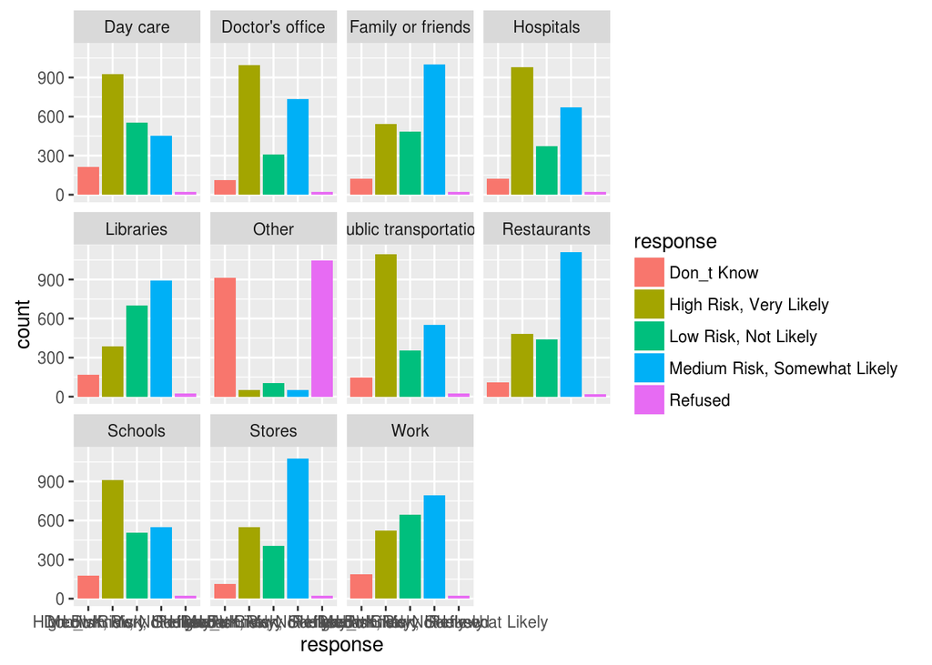

```
##                            Work                             Schools
##  Don_t Know                  :185   Don_t Know                  :178
##  High Risk, Very Likely      :524   High Risk, Very Likely      :909
##  Low Risk, Not Likely        :643   Low Risk, Not Likely        :508
##  Medium Risk, Somewhat Likely:795   Medium Risk, Somewhat Likely:551
##  Refused                     : 21   Refused                     : 22
##
##
##                          Day care                            Stores
##  Don_t Know                  :214   Don_t Know                  : 115
##  High Risk, Very Likely      :924   High Risk, Very Likely      : 551
##  Low Risk, Not Likely        :554   Low Risk, Not Likely        : 405
##  Medium Risk, Somewhat Likely:454   Medium Risk, Somewhat Likely:1076
##  Refused                     : 22   Refused                     :  21
##
##
##                        Restaurants                          Libraries
##  Don_t Know                  : 111   Don_t Know                  :169
##  High Risk, Very Likely      : 483   High Risk, Very Likely      :386
##  Low Risk, Not Likely        : 442   Low Risk, Not Likely        :700
##  Medium Risk, Somewhat Likely:1111   Medium Risk, Somewhat Likely:890
##  Refused                     :  21   Refused                     : 23
##
##
##                         Hospitals                       Doctor's office
##  Don_t Know                  :123   Don_t Know                  :110
##  High Risk, Very Likely      :982   High Risk, Very Likely      :994
##  Low Risk, Not Likely        :374   Low Risk, Not Likely        :308
##  Medium Risk, Somewhat Likely:669   Medium Risk, Somewhat Likely:733
##  Refused                     : 20   Refused                     : 23
##
##
##                   Public transportation
##  Don_t Know                  : 147
##  High Risk, Very Likely      :1093
##  Low Risk, Not Likely        : 353
##  Medium Risk, Somewhat Likely: 551
##  Refused                     :  24
##
##
##                     Family or friends                          Other
##  Don_t Know                  : 121    Don_t Know                  : 915
##  High Risk, Very Likely      : 541    High Risk, Very Likely      :  51
##  Low Risk, Not Likely        : 485    Low Risk, Not Likely        : 104
##  Medium Risk, Somewhat Likely:1000    Medium Risk, Somewhat Likely:  54
##  Refused                     :  21    Refused                     :1044
##
##
##    Other text
##         :1997
##  church :  13
##  Church :  13
##  none   :   8
##  gym    :   7
##  n/a    :   4
##  (Other): 126
```

#### 0.3.0.12 Q13. Do you get the flu vaccine?

```
##               Q13
##  No, never      :819
##  Refused        : 18
##  Yes, every year:908
##  Yes, some years:423
```

#### 0.3.0.13 Q12. Which of the following actions do you take to avoid getting sick?

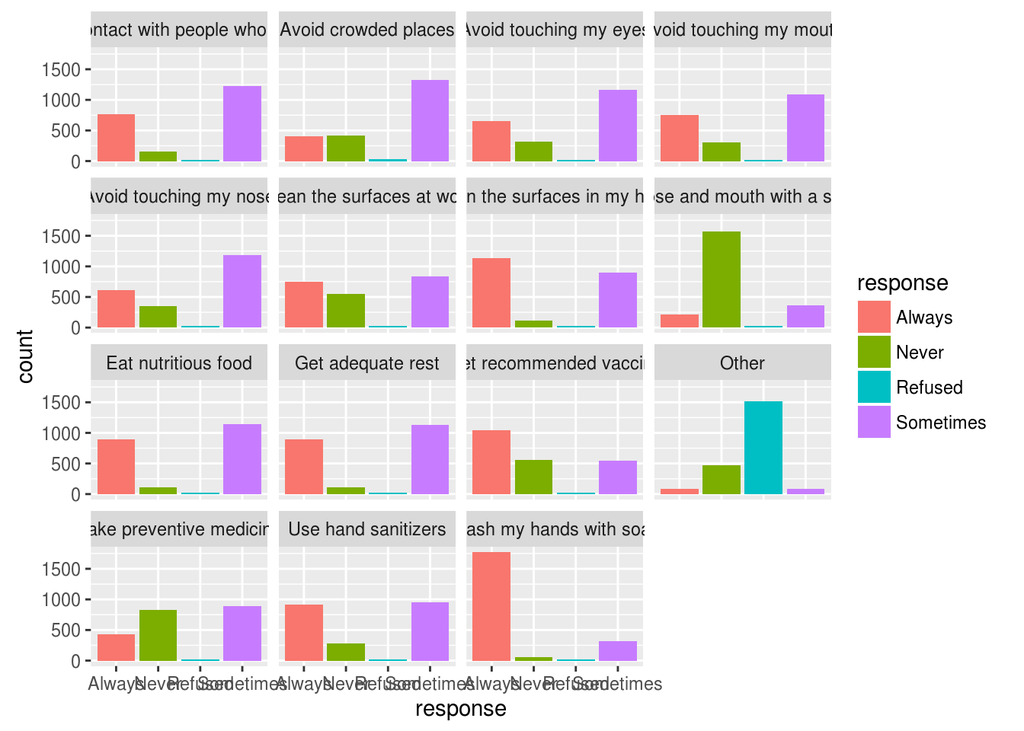

```
##  Avoid touching my eyes Avoid touching my nose Avoid touching my mouth
##  Always   : 653         Always   : 613         Always   : 758
##  Never    : 324         Never    : 349         Never    : 300
##  Refused  :  23         Refused  :  23         Refused  :  25
##  Sometimes:1168         Sometimes:1183         Sometimes:1085
##
##
##
##  Wash my hands with soap Use hand sanitizers Clean the surfaces in my home
##  Always   :1774          Always   :911       Always   :1132
##  Never    :  52          Never    :278       Never    : 115
##  Refused  :  25          Refused  : 22       Refused  :  22
##  Sometimes: 317          Sometimes:957       Sometimes: 899
##
##
##
##  Clean the surfaces at work Eat nutritious food Get adequate rest
##  Always   :752              Always   : 895      Always   : 899
##  Never    :544              Never    : 107      Never    : 114
##  Refused  : 30              Refused  :  22      Refused  :  25
##  Sometimes:842              Sometimes:1144      Sometimes:1130
##
##
##
##  Get recommended vaccine Take preventive medicine
##  Always   :1041          Always   :425
##  Never    : 564          Never    :831
##  Refused  :  23          Refused  : 22
##  Sometimes: 540          Sometimes:890
##
##
##
##  Cover my nose and mouth with a surgical mask
##  Always   : 218
##  Never    :1568
##  Refused  :  24
##  Sometimes: 358
##
##
##
##  Avoid contact with people who are sick Avoid crowded places
##  Always   : 765                         Always   : 406
##  Never    : 153                         Never    : 413
##  Refused  :  22                         Refused  :  27
##  Sometimes:1228                         Sometimes:1322
##
##
##
##        Other                  Other text
##  Always   :  91                    :2022
##  Never    : 472   none             :   7
##  Refused  :1518   stay home        :   4
##  Sometimes:  87   avoid sick people:   3
##                   N/A              :   3
##                   nothing          :   3
##                   (Other)          : 126
```

#### 0.3.0.14 Q14. How much do you pay to get an influenza vaccine?

```
##             Q14
##  $0           :970
##  $30 to $60   : 54
##  Don_t know   : 80
##  Less than $30:222
##  More than $60:  4
##  Refused      :  1
##  NA's         :837
```

#### 0.3.0.15 Q15. Are you more likely to get a vaccine if others around you get a vaccine?

```
##                Q15
##  No, less likely : 70
##  No, no effect   :878
##  Refused         :  2
##  Yes, more likely:381
##  NA's            :837
```

#### 0.3.0.16 Q16. Are you more likely to get a vaccine if others around you do not get a vaccine?

```
##                Q16
##  No, less likely :101
##  No, no effect   :904
##  Refused         : 13
##  Yes, more likely:313
##  NA's            :837
```

#### 0.3.0.17 Q17. Do you get a vaccine to protect yourself, protect others, or protect yourself and others?

```
##                         Q17
##  Protect myself           :381
##  Protect myself and others:921
##  Protect others           : 22
##  Refused                  :  7
##  NA's                     :837
```

#### 0.3.0.18 Q18. What are the reasons you would not get an influenza vaccine?

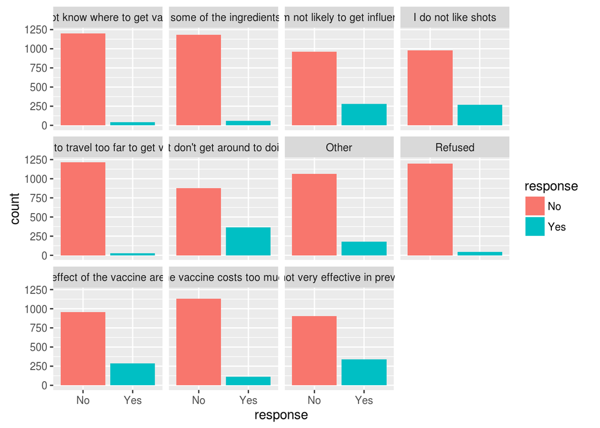

```
##  The vaccine costs too much
##  No  :1132
##  Yes : 110
##  NA's: 926
##
##
##
##
##  The vaccine is not very effective in preventing influenza
##  No  :903
##  Yes :339
##  NA's:926
##
##
##
##
##  I am not likely to get influenza Do not know where to get vaccine
##  No  :964                         No  :1199
##  Yes :278                         Yes :  43
##  NA's:926                         NA's: 926
##
##
##
##
##  The side effect of the vaccine are too risky
##  No  :958
##  Yes :284
##  NA's:926
##
##
##
##
##  I am allergic to some of the ingredients in the vaccine
##  No  :1184
##  Yes :  58
##  NA's: 926
##
##
##
##
```

[output cut: 9 more lines]

```
##  No  :1216                               No  :1064   No  :1200
##  Yes :  26                               Yes : 178   Yes :  42
##  NA's: 926                               NA's: 926   NA's: 926
##
##
##
##
##                                                             Other text
##                                                                  :1991
##  no need                                                         :   3
##  70's swine flu vacc                                             :   1
##  Always get sick when I get the shot                             :   1
##  because                                                         :   1
##  because i get treatments to lower and over active immune system.:   1
##  (Other)                                                         : 170
```

#### 0.3.0.19 Q19. Do you have health insurance?

```
##       Q19
##  No     : 154
##  Refused:  20
##  Yes    :1994
```

#### 0.3.0.20 Q20. How effective do you think the influenza vaccine is in protecting people from becoming sick with influenza?

```
##                               Q20
##  Don_t know                     :228
##  It varies from season to season:433
##  Not effective                  :144
##  Refused                        : 19
##  Somewhat effective             :961
##  Very effective                 :383
```

#### 0.3.0.21 Q21. Are influenza vaccines covered by your health insurance?

```
##                                      Q21
##  Don_t know                            : 500
##  No                                    :  55
##  Refused                               :   4
##  Yes, but only part of the cost is paid: 153
##  Yes, the full cost is paid            :1282
##  NA's                                  : 174
```

#### 0.3.0.22 Q22. Do you do any of the following when you have influenza symptoms?

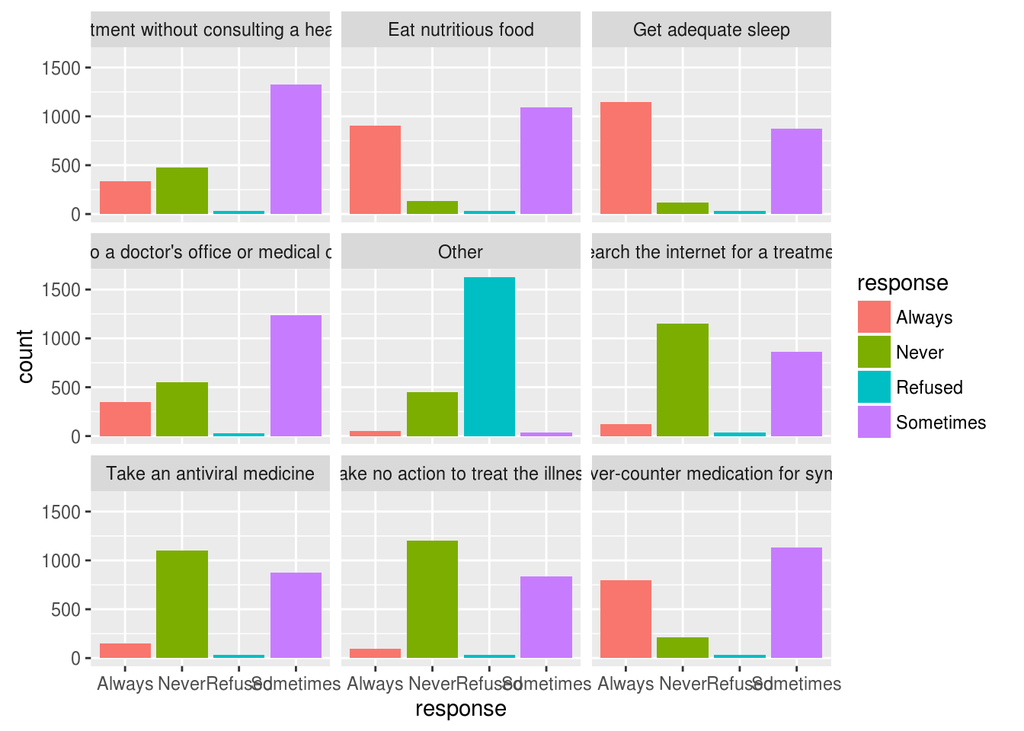

```
##  Go to a doctor's office or medical clinic
##  Always   : 349
##  Never    : 552
##  Refused  :  32
##  Sometimes:1235
##
##
##
##  Decide on treatment without consulting a health practitioner
##  Always   : 335
##  Never    : 473
##  Refused  :  31
##  Sometimes:1329
##
##
##
##  Search the internet for a treatment Get adequate sleep
##  Always   : 126                      Always   :1147
##  Never    :1148                      Never    : 115
##  Refused  :  33                      Refused  :  31
##  Sometimes: 861                      Sometimes: 875
##
##
##
##  Eat nutritious food Take-over-counter medication for symptoms
##  Always   : 909      Always   : 796
##  Never    : 135      Never    : 210
##  Refused  :  33      Refused  :  32
##  Sometimes:1091      Sometimes:1130
##
##
##
##  Take an antiviral medicine Take no action to treat the illness
##  Always   : 153             Always   :  96
##  Never    :1103             Never    :1199
##  Refused  :  35             Refused  :  34
##  Sometimes: 877             Sometimes: 839
##
##
##
##        Other                        Other text
##  Always   :  54                          :2046
##  Never    : 448   none                   :   6
##  Refused  :1628   dont know              :   2
##  Sometimes:  38   drink lots of fluids   :   2
##                   eat chicken noodle soup:   2
##                   n/a                    :   2
##                   (Other)                : 108
```

#### 0.3.0.23 Q23. Which of the following actions do you take when you have influenza symptoms to avoid someone else from getting sick?

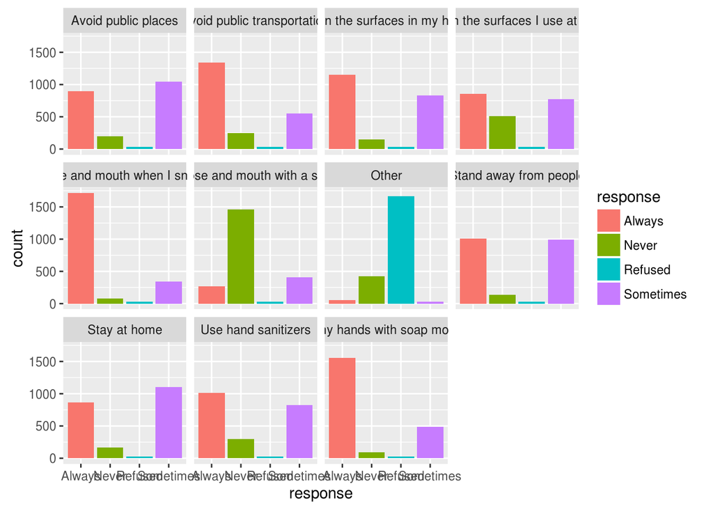

```
##  Stand away from people Avoid public places Avoid public transportation
##  Always   :1006         Always   : 897      Always   :1342
##  Never    : 135         Never    : 196      Never    : 245
##  Refused  :  31         Refused  :  31      Refused  :  31
##  Sometimes: 996         Sometimes:1044      Sometimes: 550
##
##
##
##     Stay at home  Wash my hands with soap more often Use hand sanitizers
##  Always   : 869   Always   :1559                     Always   :1014
##  Never    : 163   Never    :  92                     Never    : 299
##  Refused  :  30   Refused  :  29                     Refused  :  30
##  Sometimes:1106   Sometimes: 488                     Sometimes: 825
##
##
##
##  Clean the surfaces in my home Clean the surfaces I use at work
##  Always   :1151                Always   :856
##  Never    : 153                Never    :508
##  Refused  :  32                Refused  : 32
##  Sometimes: 832                Sometimes:772
##
##
##
##  Cover my nose and mouth with a surgical mask
##  Always   : 267
##  Never    :1463
##  Refused  :  29
##  Sometimes: 409
##
##
##
##  Cover my nose and mouth when I sneeze or cough       Other
##  Always   :1717                                 Always   :  54
##  Never    :  81                                 Never    : 421
##  Refused  :  29                                 Refused  :1665
##  Sometimes: 341                                 Sometimes:  28
##
##
##
##        Other text
##             :2078
##  none       :   6
##  stay in bed:   3
##  dont know  :   2
##  na         :   2
##  never had  :   2
##  (Other)    :  75
```

#### 0.3.0.24 Q24. What sources of information do you recall hearing or seeing about influenza outbreaks?

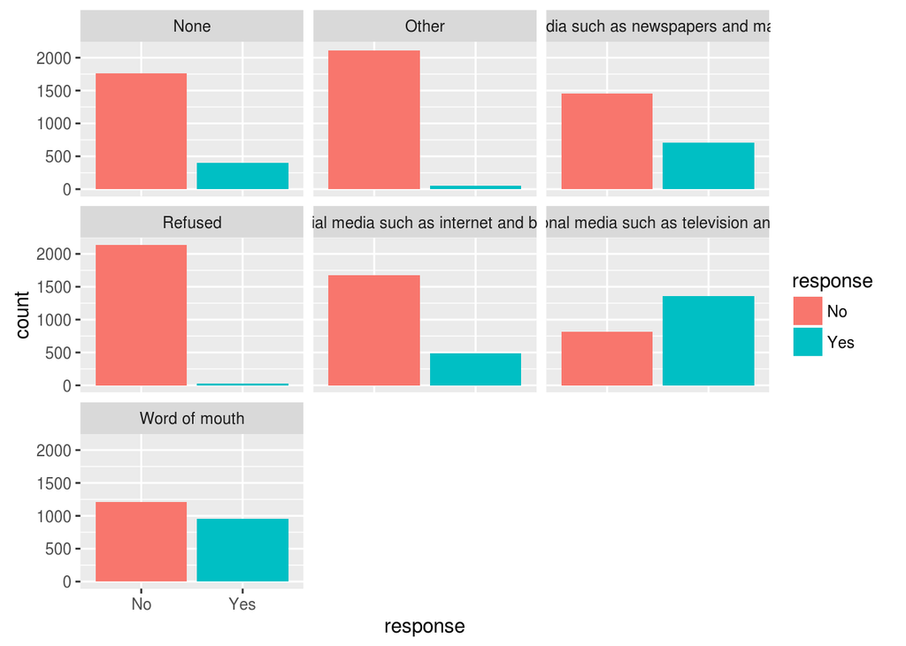

```
##  Print media such as newspapers and magazines
##  No :1460
##  Yes: 708
##
##
##
##
##
##  Traditional media such as television and radio
##  No : 811
##  Yes:1357
##
##
##
##
##
##  Social media such as internet and blogs Word of mouth  None
##  No :1680                                No :1213      No :1764
##  Yes: 488                                Yes: 955      Yes: 404
##
##
##
##
##
##  Other      Refused          Other text
##  No :2114   No :2138              :2114
##  Yes:  54   Yes:  30   CDC        :   2
##                        doctor     :   2
##                        Internet   :   2
##                        Online news:   2
##                        work       :   2
##                        (Other)    :  44
```

#### 0.3.0.25 Q25. If you received information from the news, internet or other public media that there was an influenza outbreak in your community would you do any of the following?

```
##  Stand away from people Avoid public places Avoid public transportation
##  Always   : 649         Always   : 648      Always   :1221
##  Never    : 217         Never    : 270      Never    : 268
##  Refused  :  34         Refused  :  33      Refused  :  36
##  Sometimes:1268         Sometimes:1217      Sometimes: 643
##
##
##
##     Stay at home  Wash my hands with soap more often Use hand sanitizers
##  Always   : 484   Always   :1477                     Always   :1077
##  Never    : 429   Never    :  99                     Never    : 257
##  Refused  :  33   Refused  :  38                     Refused  :  35
##  Sometimes:1222   Sometimes: 554                     Sometimes: 799
##
##
##
##  Clean the surfaces in my home Clean the surfaces I use at work
##  Always   :1116                Always   :902
##  Never    : 160                Never    :464
##  Refused  :  35                Refused  : 36
##  Sometimes: 857                Sometimes:766
##
##
##
##  Cover my nose and mouth with a surgical mask
##  Always   : 343
##  Never    :1286
##  Refused  :  34
##  Sometimes: 505
##
##
##
##  Cover my nose and mouth when I sneeze or cough       Other
##  Always   :1643                                 Always   :  32
##  Never    :  90                                 Never    : 393
##  Refused  :  36                                 Refused  :1722
##  Sometimes: 399                                 Sometimes:  21
##
##
##
##      Other text
##           :2100
##  none     :   9
##  nothing  :   3
##  n/a      :   2
##  stay home:   2
##  -        :   1
##  (Other)  :  51
```

#### 0.3.0.26 Q26. Does your household have children?

```
##       Q26
##  No     :1570
##  Refused:  22
##  Yes    : 576
```

#### 0.3.0.27 Q27. What actions do you take when a child in your household has influenza symptoms?

```
##  Keep the child away from the others in the residence
##  Always   : 198
##  Never    :  90
##  Refused  :   3
##  Sometimes: 285
##  NA's     :1592
##
##
##  Keep the child out of school/daycare
##  Always   : 377
##  Never    :  46
##  Refused  :   4
##  Sometimes: 149
##  NA's     :1592
##
##
##  Stop child's social activities like play dates       Other
##  Always   : 388                                 Always   :  12
##  Never    :  41                                 Never    :  93
##  Refused  :   3                                 Refused  : 459
##  Sometimes: 144                                 Sometimes:  12
##  NA's     :1592                                 NA's     :1592
##
##
##                                                                Other text
##                                                                     :2147
##  Consult with the child's doctors.                                  :   1
##  crawling on floor                                                  :   1
##  Depending on symptoms id have him wear a mask to help us not get it:   1
##  doctor visit                                                       :   1
##  give supplements & herbs                                           :   1
##  (Other)                                                            :  16
```

#### 0.3.0.28 Q28. Are you a single parent?

```
##    Q28
##  No  : 490
##  Yes :  86
##  NA's:1592
```

#### 0.3.0.29 Q29. How do you care for a sick child?

```
##  A parent brings the child to work A parent stays home
##  Always   :   7                    Always   : 266
##  Never    : 438                    Never    :  27
##  Refused  :   4                    Refused  :   4
##  Sometimes:  41                    Sometimes: 193
##  NA's     :1678                    NA's     :1678
##
##
##  Another adult stays home Send the child to school sick
##  Always   :  68           Always   :   1
##  Never    : 202           Never    : 414
##  Refused  :   4           Refused  :   5
##  Sometimes: 216           Sometimes:  70
##  NA's     :1678           NA's     :1678
##
##
##  Take the child to a relative or friends       Other
##  Always   :   8                          Always   :   4
##  Never    : 292                          Never    :  76
##  Refused  :   4                          Refused  : 404
##  Sometimes: 186                          Sometimes:   6
##  NA's     :1678                          NA's     :1678
##
##
##                                                                                 Other text
##                                                                                      :2157
##  Because of proper diets and physical training my family stays healthy the year round:   1
##  Child stays home alone                                                              :   1
##  child stays home alone, old enough to take care of himself                          :   1
##  drive to school                                                                     :   1
##  Have the student sleep more and work less (on school stuff).                        :   1
##  (Other)                                                                             :   6
```

#### 0.3.0.30 Q30. How do you care for a sick child?

```
##  I bring the child to work    I stay home   Another adult stays home
##  Always   :   4            Always   :  34   Always   :   9
##  Never    :  77            Never    :  10   Never    :  25
##  Sometimes:   5            Sometimes:  42   Sometimes:  52
##  NA's     :2082            NA's     :2082   NA's     :2082
##
##  Send the child to school sick Take the child to a relative or friends
##  Always   :   3                Always   :   7
##  Never    :  60                Never    :  33
##  Sometimes:  23                Sometimes:  46
##  NA's     :2082                NA's     :2082
##
##        Other                             Other text
##  Always   :   1                               :2165
##  Never    :  14   adult child                 :   1
##  Refused  :  68   Hes old enough to stay alone:   1
##  Sometimes:   3   my children are grown       :   1
##  NA's     :2082
```

#### 0.3.0.31 Q31. How many hours of screen time (time spent watching television, a computer, smartphone, iPad, etc.) do you spend each day on average when you are not sick? Enter 0 if none

```
##       Q31           Q31_Codes
##  Min.   : 0.000   Refused:  52
##  1st Qu.: 2.000   NA's   :2116
##  Median : 4.000
##  Mean   : 4.868
##  3rd Qu.: 6.000
##  Max.   :24.000
##  NA's   :52
```

#### 0.3.0.32 Q32. How many hours of screen time do you spend each day on average when you are sick? Enter 0 if none

```
##       Q32           Q32_Codes
##  Min.   : 0.000   Refused:  61
##  1st Qu.: 1.000   NA's   :2107
##  Median : 4.000
##  Mean   : 4.267
##  3rd Qu.: 6.000
##  Max.   :24.000
##  NA's   :61
```

#### 0.3.0.33 Q33. How many people, including yourself, reside in your household?

```
##       Q33          Q33_Codes
##  Min.   : 1.00   Refused:  28
##  1st Qu.: 2.00   NA's   :2140
##  Median : 2.00
##  Mean   : 2.58
##  3rd Qu.: 3.00
##  Max.   :14.00
##  NA's   :28
```

# 1 Household members

```
##       Q35           Q36             Q36_Codes         Q37
##  Female :799   Min.   :0.000   Don_t know:  61   Min.   :0.000
##  Male   :859   1st Qu.:0.000   Refused   :   5   1st Qu.:0.000
##  Refused:  5   Median :4.000   NA's      :2102   Median :2.000
##  NA's   :505   Mean   :2.873                     Mean   :2.098
##                3rd Qu.:5.000                     3rd Qu.:3.000
##                Max.   :7.000                     Max.   :7.000
##                NA's   :571                       NA's   :663
##       Q37_Codes         Q38              Q38_Codes
##  Don_t know: 143   Min.   :0.0000   Don_t know:  58
##  Refused   :  15   1st Qu.:0.0000   Refused   :  19
##  NA's      :2010   Median :0.0000   NA's      :2091
##                    Mean   :0.3909
##                    3rd Qu.:0.0000
##                    Max.   :7.0000
##                    NA's   :582
##                       Q39                 Q40               Q41
##  Don_t know             : 84   1 to 2 times :1025   Never     :807
##  Less than once per year:222   3 to 5 times : 271   Once      :400
##  More than once per year:593   Never        : 226   2 times   :191
##  Never                  :100   Don_t know   :  87   Don_t know:158
##  Once per year          :656   6 to 10 times:  32   3 times   : 60
##  Refused                :  8   (Other)      :  22   (Other)   : 47
##  NA's                   :505   NA's         : 505   NA's      :505
##              Q42
##  Don_t know    :166
##  No, never     :567
##  Refused       :  6
##  Yes, always   :661
##  Yes, sometimes:263
##  NA's          :505
##
```

```
##       Q43            Q44             Q44_Codes         Q45
##  Female : 388   Min.   :0.000   Don_t know:  40   Min.   :0.000
##  Male   : 431   1st Qu.:1.000   Refused   :   3   1st Qu.:1.000
##  Refused:   9   Median :5.000   NA's      :2125   Median :2.000
##  NA's   :1340   Mean   :3.669                     Mean   :2.395
##                 3rd Qu.:5.000                     3rd Qu.:4.000
##                 Max.   :7.000                     Max.   :7.000
##                 NA's   :1383                      NA's   :1419
##       Q45_Codes         Q46              Q46_Codes
##  Don_t know:  70   Min.   :0.0000   Don_t know:  42
##  Refused   :   9   1st Qu.:0.0000   Refused   :   9
##  NA's      :2089   Median :0.0000   NA's      :2117
##                    Mean   :0.5727
##                    3rd Qu.:0.0000
##                    Max.   :7.0000
##                    NA's   :1391
##                       Q47                  Q48               Q49
##  Don_t know             :  55   1 to 2 times : 490   Never     : 403
##  Less than once per year: 125   3 to 5 times : 153   Once      : 183
##  More than once per year: 232   Never        :  83   Don_t know:  93
##  Never                  :  59   Don_t know   :  66   2 times   :  91
##  Once per year          : 353   6 to 10 times:  25   3 times   :  32
##  Refused                :   4   (Other)      :  11   (Other)   :  26
##  NA's                   :1340   NA's         :1340   NA's      :1340
##              Q50
##  Don_t know    : 100
##  No, never     : 317
##  Refused       :   4
##  Yes, always   : 275
##  Yes, sometimes: 132
##  NA's          :1340
##
```

## 1.1 HHM1

#### 1.1.0.1 Q35. What is the gender of this member of the household? Remember, this relates to HHM1_Name who is HHM1_AGE years old.

```
##       Q35
##  Female :799
##  Male   :859
##  Refused:  5
##  NA's   :505
```

#### 1.1.0.2 Q36. On average, how many days per week does this member of your household work or attend day care or school outside of your home?

```
##       Q36             Q36_Codes
##  Min.   :0.000   Don_t know:  61
##  1st Qu.:0.000   Refused   :   5
##  Median :4.000   NA's      :2102
##  Mean   :2.873
##  3rd Qu.:5.000
##  Max.   :7.000
##  NA's   :571
```

#### 1.1.0.3 Q37. On average, how many days per week does this member of your household participate in social activities outside of your home?

```
##       Q37             Q37_Codes
##  Min.   :0.000   Don_t know: 143
##  1st Qu.:0.000   Refused   :  15
##  Median :2.000   NA's      :2010
##  Mean   :2.098
##  3rd Qu.:3.000
##  Max.   :7.000
##  NA's   :663
```

#### 1.1.0.4 Q38. On average, how many days per week does this member of your household use public transportation?

```
##       Q38              Q38_Codes
##  Min.   :0.0000   Don_t know:  58
##  1st Qu.:0.0000   Refused   :  19
##  Median :0.0000   NA's      :2091
##  Mean   :0.3909
##  3rd Qu.:0.0000
##  Max.   :7.0000
##  NA's   :582
```

#### 1.1.0.5 Q39. How frequently does this member of your household visit a doctorÕs office for wellness appointments?

```
##                       Q39
##  Don_t know             : 84
##  Less than once per year:222
##  More than once per year:593
##  Never                  :100
##  Once per year          :656
##  Refused                :  8
##  NA's                   :505
```

#### 1.1.0.6 Q40. How frequently does this member of the household get sick in a typical year?

```
##             Q40
##  1 to 2 times :1025
##  3 to 5 times : 271
##  Never        : 226
##  Don_t know   :  87
##  6 to 10 times:  32
##  (Other)      :  22
##  NA's         : 505
```

#### 1.1.0.7 Q41. How many times has this member of your household had influenza or another respiratory illness in the last two years?

```
##          Q41
##  Never     :807
##  Once      :400
##  2 times   :191
##  Don_t know:158
##  3 times   : 60
##  (Other)   : 47
##  NA's      :505
```

#### 1.1.0.8 Q42. Does this member of your household get an annual influenza vaccine?

```
##              Q42
##  Don_t know    :166
##  No, never     :567
##  Refused       :  6
##  Yes, always   :661
##  Yes, sometimes:263
##  NA's          :505
```

## 1.2 HHM2

#### 1.2.0.1 Q43. What is the gender of this member of the household? Remember, this relates to HHM1_Name who is HHM1_AGE years old.

```
##       Q43
##  Female : 388
##  Male   : 431
##  Refused:   9
##  NA's   :1340
```

#### 1.2.0.2 Q44. On average, how many days per week does this member of your household work or attend day care or school outside of your home?

```
##       Q44             Q44_Codes
##  Min.   :0.000   Don_t know:  40
##  1st Qu.:1.000   Refused   :   3
##  Median :5.000   NA's      :2125
##  Mean   :3.669
##  3rd Qu.:5.000
##  Max.   :7.000
##  NA's   :1383
```

#### 1.2.0.3 Q45. On average, how many days per week does this member of your household participate in social activities outside of your home?

```
##       Q45             Q45_Codes
##  Min.   :0.000   Don_t know:  70
##  1st Qu.:1.000   Refused   :   9
##  Median :2.000   NA's      :2089
##  Mean   :2.395
##  3rd Qu.:4.000
##  Max.   :7.000
##  NA's   :1419
```

#### 1.2.0.4 Q46. On average, how many days per week does this member of your household use public transportation?

```
##       Q46              Q46_Codes
##  Min.   :0.0000   Don_t know:  42
##  1st Qu.:0.0000   Refused   :   9
##  Median :0.0000   NA's      :2117
##  Mean   :0.5727
##  3rd Qu.:0.0000
##  Max.   :7.0000
##  NA's   :1391
```

#### 1.2.0.5 Q47. How frequently does this member of your household visit a doctorÕs office for wellness appointments?

```
##                       Q47
##  Don_t know             :  55
##  Less than once per year: 125
##  More than once per year: 232
##  Never                  :  59
##  Once per year          : 353
##  Refused                :   4
##  NA's                   :1340
```

#### 1.2.0.6 Q48. How frequently does this member of the household get sick in a typical year?

```
##             Q48
##  1 to 2 times : 490
##  3 to 5 times : 153
##  Never        :  83
##  Don_t know   :  66
##  6 to 10 times:  25
##  (Other)      :  11
##  NA's         :1340
```

#### 1.2.0.7 Q49. How many times has this member of your household had influenza or another respiratory illness in the last two years?

```
##          Q49
##  Never     : 403
##  Once      : 183
##  Don_t know:  93
##  2 times   :  91
##  3 times   :  32
##  (Other)   :  26
##  NA's      :1340
```

#### 1.2.0.8 Q50. Does this member of your household get an annual influenza vaccine?

```
##              Q50
##  Don_t know    : 100
##  No, never     : 317
##  Refused       :   4
##  Yes, always   : 275
##  Yes, sometimes: 132
##  NA's          :1340
```

## 1.3 to-do:

- need to remove NA’s
- ggplot(q7) + geom_bar(aes(x = option, fill = response), position = “dodge”)
- ggplot(data = data) + geom_bar(mapping = aes(x = Q1)) + stat_sum()